# Proyecto_Leo

```r
## Porcentaje de genes que retuvimos
round(nrow(rse_gene_SRP220466) / nrow(rse_gene_SRP220466_unfiltered) * 100, 2)
```

```
## [1] 53.36
```

```r
# Normalizamos los datos
library("edgeR")
dge <- DGEList(
    counts = assay(rse_gene_SRP220466, "counts"),
    genes = rowData(rse_gene_SRP220466)
)
dge <- calcNormFactors(dge)
```

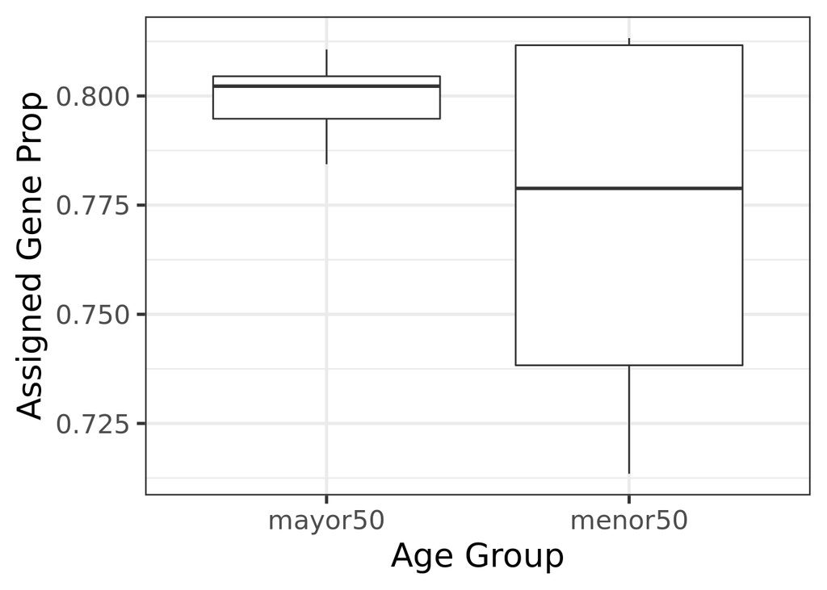

```r
# Exploramos los datos que consideramos para este proyecto
library("ggplot2")
ggplot(as.data.frame(colData(rse_gene_SRP220466)), aes(y = assigned_gene_prop, x = menor50)) +
    geom_boxplot() +
    theme_bw(base_size = 20) +
    ylab("Assigned Gene Prop") +
    xlab("Age Group")
```

Aqui podemos encontrar como los menores se encuentran en rangos mas bajos del promedio que se hizo en assigned_gene_prop

```r
# Continuamos haciendo otro modelo para seguir analizando nuestros datos
mod <- model.matrix(~ menor50 + sra_attribute.age + sra_attribute.gender + assigned_gene_prop,
    data = colData(rse_gene_SRP220466)
)
colnames(mod)
```

```
## [1] "(Intercept)"              "menor50menor50"
## [3] "sra_attribute.age"        "sra_attribute.gendermale"
## [5] "assigned_gene_prop"
```

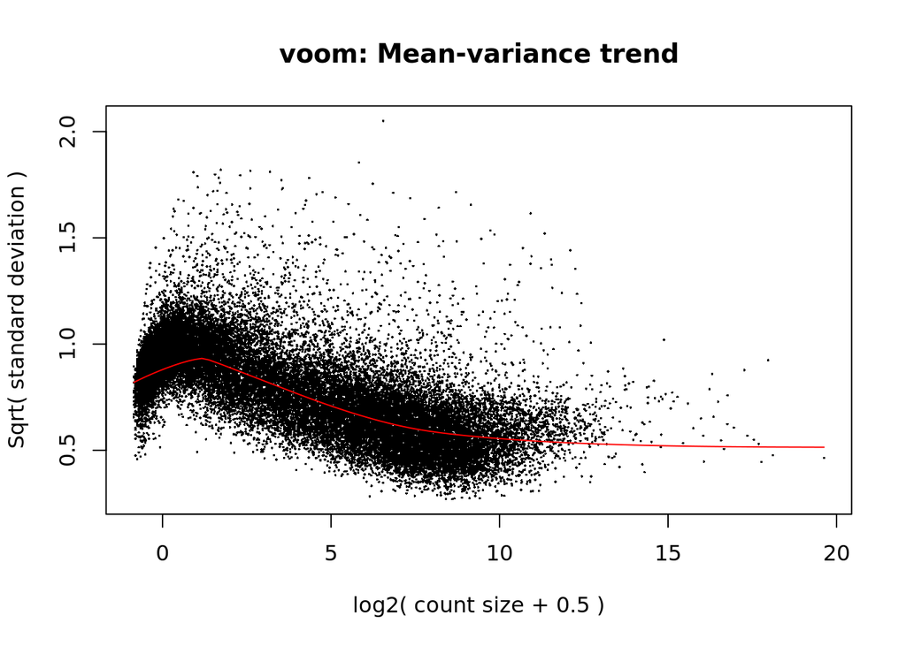

```r
# Ya teniendo el modelo estadístico, podemos usar limma para realizar el análisis de expresión diferencial
library("limma")
vGene <- voom(dge, mod, plot = TRUE)
```

Aqui podemos ver como nuestro modelo tiene una buena respresentacion con el modelo de Voom, es relativamente buena aunque algunos datos siguen excediendo limites posiblemente se necesite limpiar un poco mas.

```r
# Con eBayes se espera calcular Estadísticas Empíricas De Bayes Para Expresión Diferencial
# y con lmFit se ajustara el modelo lineal para cada gen dada una serie de matrices
eb_results <- eBayes(lmFit(vGene))
# Y extraemos una tabla de los genes mejor clasificados de un ajuste de modelo lineal
de_results <- topTable(
    eb_results,
    coef = 2,
    number = nrow(rse_gene_SRP220466),
    sort.by = "none"
)
dim(de_results)
```

```
## [1] 34071    16
```

```r
# Visualizamos los resultados
head(de_results)
```

```
##                    source type score phase           gene_id
## ENSG00000223972.5  HAVANA gene  1735    NA ENSG00000223972.5
## ENSG00000278267.1 ENSEMBL gene    68    NA ENSG00000278267.1
## ENSG00000227232.5  HAVANA gene  1351    NA ENSG00000227232.5
## ENSG00000243485.5  HAVANA gene  1021    NA ENSG00000243485.5
## ENSG00000237613.2  HAVANA gene  1219    NA ENSG00000237613.2
## ENSG00000239945.1  HAVANA gene  1319    NA ENSG00000239945.1
##                                            gene_type    gene_name level
## ENSG00000223972.5 transcribed_unprocessed_pseudogene      DDX11L1     2
## ENSG00000278267.1                              miRNA    MIR6859-1     3
## ENSG00000227232.5             unprocessed_pseudogene       WASH7P     2
## ENSG00000243485.5                            lincRNA  MIR1302-2HG     2
## ENSG00000237613.2                            lincRNA      FAM138A     2
## ENSG00000239945.1                            lincRNA RP11-34P13.8     2
##                            havana_gene               tag      logFC   AveExpr
## ENSG00000223972.5 OTTHUMG00000000961.2              <NA> -0.4851759 -3.163481
## ENSG00000278267.1                 <NA>              <NA>  0.2872308 -2.226889
## ENSG00000227232.5 OTTHUMG00000000958.1              <NA>  0.2813880  3.002264
## ENSG00000243485.5 OTTHUMG00000000959.2        ncRNA_host  0.7529791 -3.414602
## ENSG00000237613.2 OTTHUMG00000000960.1              <NA> -0.5159871 -4.147144
## ENSG00000239945.1 OTTHUMG00000001097.2 overlapping_locus -0.3465695 -2.521582
##                            t   P.Value adj.P.Val         B
## ENSG00000223972.5 -0.5220502 0.6083852 0.9745571 -4.794470
## ENSG00000278267.1  0.3333837 0.7429297 0.9777587 -4.812925
## ENSG00000227232.5  0.7239717 0.4789487 0.9745571 -5.057664
## ENSG00000243485.5  0.8549308 0.4045019 0.9745571 -4.716930
## ENSG00000237613.2 -0.7955744 0.4372703 0.9745571 -4.754796
## ENSG00000239945.1 -0.3290521 0.7461437 0.9777587 -4.811577
```

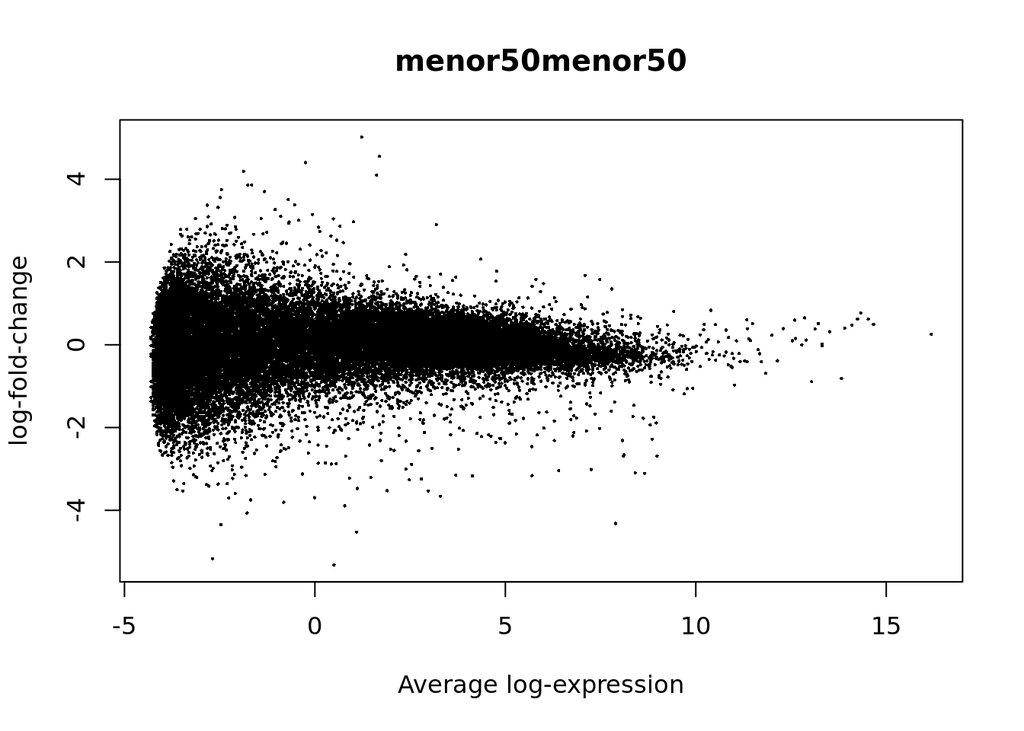

```r
## Visualicemos los resultados estadísticos
plotMA(eb_results, coef = 2)
```

Un MAplot representa la expresión logarítmica promedio frente a la relación promedio (o cambio de veces) entre dos condiciones, en este caso los valores no se alejan tanto del cero lo que nos da una buena señal.

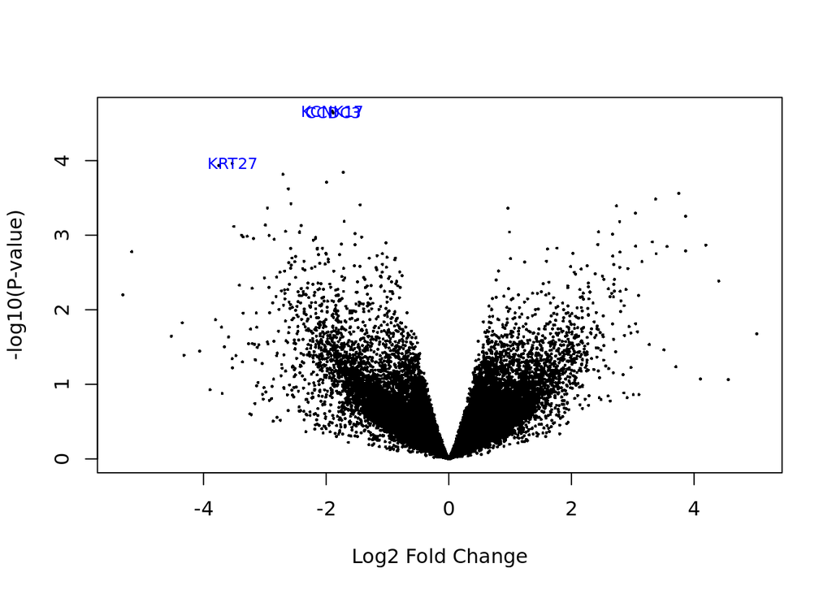

```r
volcanoplot(eb_results, coef = 2, highlight = 3, names = de_results$gene_name)
```

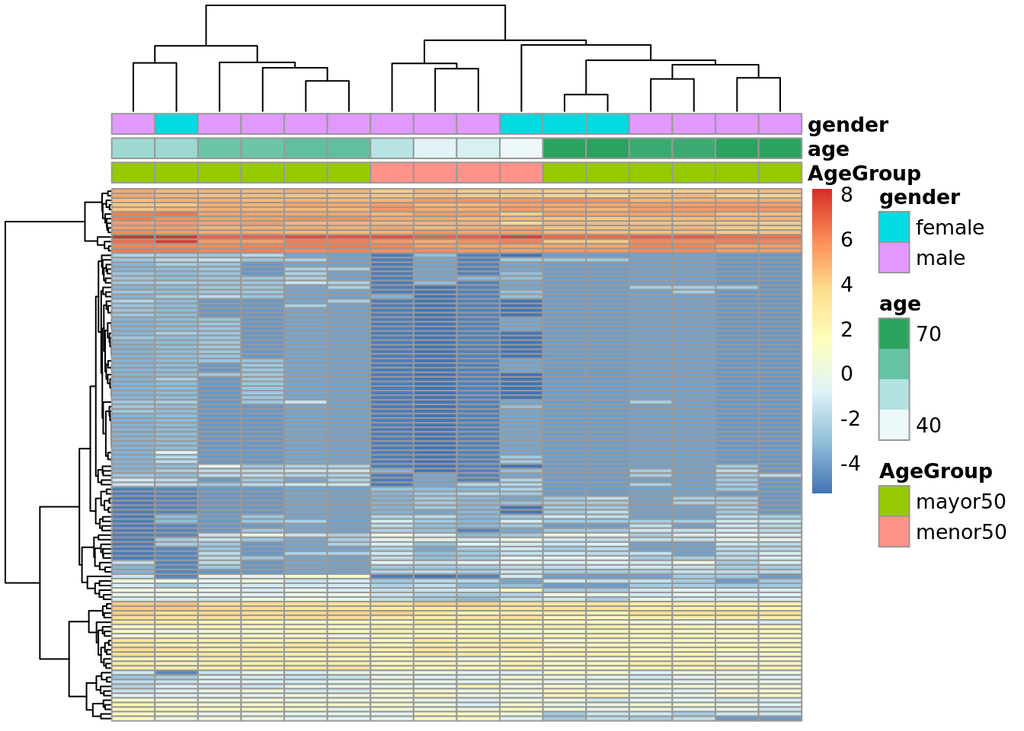

```r
## Extraer valores de los genes de interés
exprs_heatmap <- vGene$E[rank(de_results$adj.P.Val) <= 60, ]

## Creemos una tabla con información de las muestras
## y con nombres de columnas más amigables
df <- as.data.frame(colData(rse_gene_SRP220466)[, c("menor50", "sra_attribute.age", "sra_attribute.gender")])
colnames(df) <- c("AgeGroup", "age", "gender")

## Hagamos un heatmap
library("pheatmap")
pheatmap(
    exprs_heatmap,
    cluster_rows = TRUE,
    cluster_cols = TRUE,
    show_rownames = FALSE,
    show_colnames = FALSE,
    annotation_col = df
)
```

Con estos datos podemos ver que en los grupos menores de 50 es donde se encuentran los valores mas pequeños

```r
library("RColorBrewer")

## Conviertiendo los grupos de edad a colores
col.group <- df$AgeGroup
levels(col.group) <- brewer.pal(nlevels(col.group), "Set1")
```

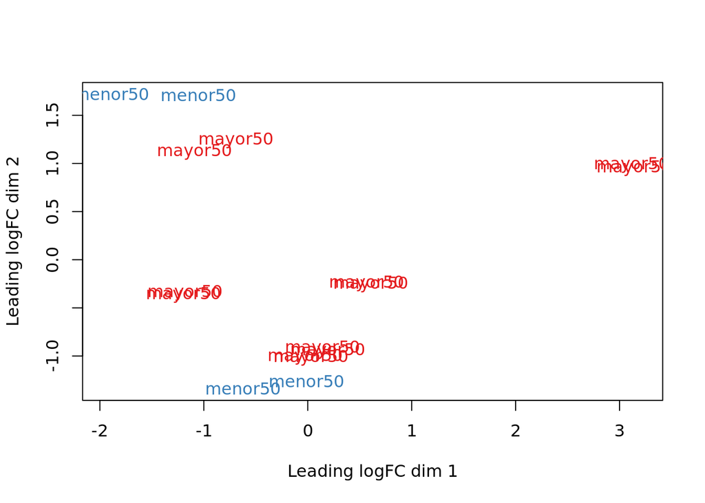

```r
col.group <- as.character(col.group)

## MDS por grupos de edad
plotMDS(vGene$E, labels = df$AgeGroup, col = col.group)
```

```r
## Conviertiendo los valores de Gender a colores
col.gender <- df$gender
levels(col.gender) <- brewer.pal(nlevels(col.gender), "Dark2")
```

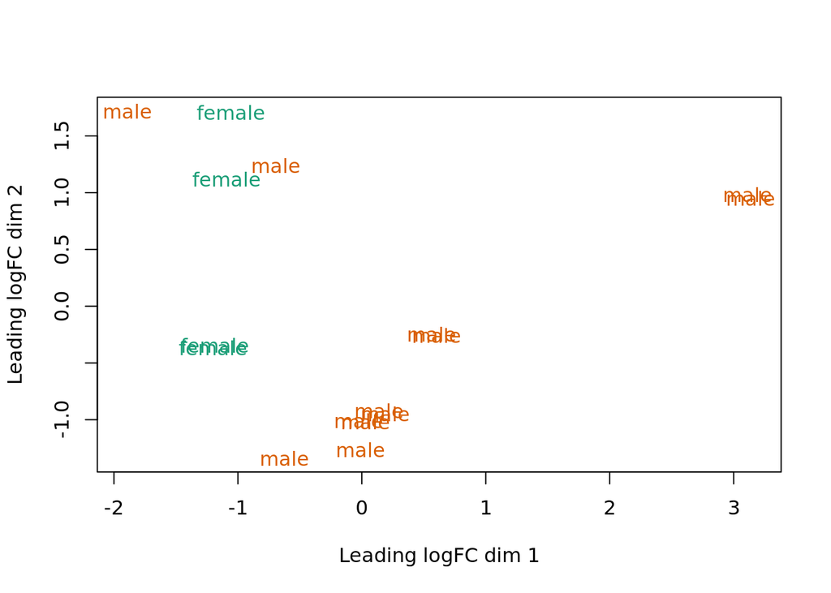

```r
col.gender <- as.character(col.gender)

## MDS por sexo
plotMDS(vGene$E, labels = df$gender, col = col.gender)
```

En las dos graficas anteriores podemos ver como se agrupan estadisticamente los hombres y mujeres en este estudio de envejecimeinto auricular, tambien vemos si son mayores de 50 o menores, para saber en que sexo se da más esta condicion y en que edad comienza